# Analise COVID-19

Lucas Mangno

29/06/2020

```r
knitr::opts_chunk$set(echo = TRUE)
```

## 1 Objetivo

O objetivo desta atividade é aplicar os conceitos das aulas do minicurso de analise e vizuaisação de dados. Minicurso que faz parte do calendario especial da UFPB. Todas as analises feitas aqui são apenas para praticar os conceitos aprendidos até então. Os dados foram tirados do site https://covid.saude.gov.br/. Tudo isso dito, agora a coisa irá ficar mais informal :) (na verdade não terá formalidade nenhuma)

## 1.1 Objetivo verdadeiro

Quem gosta de relatórios chatos e sonolentos? Eu respondo: O gerente do seu banco, já que nós não somos gerentes de nada não precisamos nos matar para ler um relatório que poder ser muito bem explicado e informativo E NÃO SER CHATO (queria dizer isso para meu chefe). Vou tratar o caso com o máximo de respeito, mas de vez ou outra teremos algumas piadinhas por isso não se zangue, afinal é tudo pela ARTE DE FAZER ANALISES… acredite ela existe.

## 2 Importando tudo

### Antes de tudo

Removendo as notações cientificas dos valores, até porque ninguém merece ver os gráficos 9+01

```r
options(scipen = 999)
```

Agora as bibliotecas

```r
library(tidyverse) # conjunto de pacotes que sempre iremos usar
library(geofacet) # organiza plots de acordo com região
library(here) # acesso a arquivos relativos à partir da raíz do projeto
library(lubridate) # manipulação de datas (tidyverse)
library(patchwork) # organiza o layout dos plots
library(readxl) # carrega arquivos excel (tidyverse)
library(scales) # funções úteis para lidar com escalas de gráficos
library(zoo) # função de média móvel (rolling average)
library(outliers) # função para melhorar a detecção de outliers
```

## 3 Carregando os dados

Vamos começar a brincadeira, primeiro passo é saber onde encontrar os dados. Onde a Globo encontra? a Record? a BAND? o STB… peraí o STB tem jornal? O grande professor [Marcus Carvalho](https://github.com/marcuswac) nos deu o site oficial do governo para baixar os dados, então valeu professor. Caso você seja preguiçoso como eu e não queira dar um google pra saber isso, o link está mais acima se nem isso você quer procurar, filho você precisa de ajuda.

```r
dados_covid <- read_xlsx("HIST_PAINEL_COVIDBR_28jun2020.xlsx", guess_max = 100000)

glimpse(dados_covid)
```

```
## Rows: 501,982
## Columns: 17
## $ regiao                <chr> "Brasil", "Brasil", "Brasil", "Brasil", "Bras...
## $ estado                <chr> NA, NA, NA, NA, NA, NA, NA, NA, NA, NA, NA, N...
## $ municipio             <chr> NA, NA, NA, NA, NA, NA, NA, NA, NA, NA, NA, N...
## $ coduf                 <chr> "76", "76", "76", "76", "76", "76", "76", "76...
## $ codmun                <dbl> NA, NA, NA, NA, NA, NA, NA, NA, NA, NA, NA, N...
## $ codRegiaoSaude        <dbl> NA, NA, NA, NA, NA, NA, NA, NA, NA, NA, NA, N...
## $ nomeRegiaoSaude       <chr> NA, NA, NA, NA, NA, NA, NA, NA, NA, NA, NA, N...
## $ data                  <dttm> 2020-02-25, 2020-02-26, 2020-02-27, 2020-02-...
## $ semanaEpi             <dbl> 9, 9, 9, 9, 9, 10, 10, 10, 10, 10, 10, 10, 11...
## $ populacaoTCU2019      <chr> "210147125", "210147125", "210147125", "21014...
## $ casosAcumulado        <dbl> 0, 1, 1, 1, 2, 2, 2, 2, 3, 7, 13, 19, 25, 25,...
## $ casosNovos            <dbl> 0, 1, 0, 0, 1, 0, 0, 0, 1, 4, 6, 6, 6, 0, 9, ...
## $ obitosAcumulado       <dbl> 0, 0, 0, 0, 0, 0, 0, 0, 0, 0, 0, 0, 0, 0, 0, ...
## $ obitosNovos           <dbl> 0, 0, 0, 0, 0, 0, 0, 0, 0, 0, 0, 0, 0, 0, 0, ...
## $ Recuperadosnovos      <dbl> NA, NA, NA, NA, NA, NA, NA, NA, NA, NA, NA, N...
## $ emAcompanhamentoNovos <dbl> NA, NA, NA, NA, NA, NA, NA, NA, NA, NA, NA, N...
## $ FgMetro               <dbl> NA, NA, NA, NA, NA, NA, NA, NA, NA, NA, NA, N...
```

O arquivo fornecido pelo Ministério da Saúde possui dados agregados em 3 níveis de agregação: para todo o Brasil, por estado e por município. Nem pra separar bonitinho o governo serve, sei não viu.

Vamos dar uma olhada como está esse Dataframe

```r
head(dados_covid)
```

```
## # A tibble: 6 x 17
##   regiao estado municipio coduf codmun codRegiaoSaude nomeRegiaoSaude
##   <chr>  <chr>  <chr>     <chr>  <dbl>          <dbl> <chr>
## 1 Brasil <NA>   <NA>      76        NA             NA <NA>
## 2 Brasil <NA>   <NA>      76        NA             NA <NA>
## 3 Brasil <NA>   <NA>      76        NA             NA <NA>
## 4 Brasil <NA>   <NA>      76        NA             NA <NA>
## 5 Brasil <NA>   <NA>      76        NA             NA <NA>
## 6 Brasil <NA>   <NA>      76        NA             NA <NA>
## # ... with 10 more variables: data <dttm>, semanaEpi <dbl>,
## #   populacaoTCU2019 <chr>, casosAcumulado <dbl>, casosNovos <dbl>,
## #   obitosAcumulado <dbl>, obitosNovos <dbl>, Recuperadosnovos <dbl>,
## #   emAcompanhamentoNovos <dbl>, FgMetro <dbl>
```

Só tem NA nisso… temos que dar um jeito.

## 3.1 Explorando

Praticamente um Indiana Jones da análise de dados, percebi que esses dados tem muitos valores faltando, vamos excluir alguns deles para quem tem toque não surtar, esses valores faltando são retornados como NA

```r
covid <- dados_covid%>%
  filter(is.na(estado), is.na(codmun))

glimpse(covid)
```

```
## Rows: 125
## Columns: 17
## $ regiao                <chr> "Brasil", "Brasil", "Brasil", "Brasil", "Bras...
## $ estado                <chr> NA, NA, NA, NA, NA, NA, NA, NA, NA, NA, NA, N...
## $ municipio             <chr> NA, NA, NA, NA, NA, NA, NA, NA, NA, NA, NA, N...
## $ coduf                 <chr> "76", "76", "76", "76", "76", "76", "76", "76...
## $ codmun                <dbl> NA, NA, NA, NA, NA, NA, NA, NA, NA, NA, NA, N...
## $ codRegiaoSaude        <dbl> NA, NA, NA, NA, NA, NA, NA, NA, NA, NA, NA, N...
## $ nomeRegiaoSaude       <chr> NA, NA, NA, NA, NA, NA, NA, NA, NA, NA, NA, N...
## $ data                  <dttm> 2020-02-25, 2020-02-26, 2020-02-27, 2020-02-...
## $ semanaEpi             <dbl> 9, 9, 9, 9, 9, 10, 10, 10, 10, 10, 10, 10, 11...
## $ populacaoTCU2019      <chr> "210147125", "210147125", "210147125", "21014...
## $ casosAcumulado        <dbl> 0, 1, 1, 1, 2, 2, 2, 2, 3, 7, 13, 19, 25, 25,...
## $ casosNovos            <dbl> 0, 1, 0, 0, 1, 0, 0, 0, 1, 4, 6, 6, 6, 0, 9, ...
## $ obitosAcumulado       <dbl> 0, 0, 0, 0, 0, 0, 0, 0, 0, 0, 0, 0, 0, 0, 0, ...
## $ obitosNovos           <dbl> 0, 0, 0, 0, 0, 0, 0, 0, 0, 0, 0, 0, 0, 0, 0, ...
## $ Recuperadosnovos      <dbl> NA, NA, NA, NA, NA, NA, NA, NA, NA, NA, NA, N...
## $ emAcompanhamentoNovos <dbl> NA, NA, NA, NA, NA, NA, NA, NA, NA, NA, NA, N...
## $ FgMetro               <dbl> NA, NA, NA, NA, NA, NA, NA, NA, NA, NA, NA, N...
```

Pronto, agora podemos começar a brincar bunitinho…

## 3.2 “To só dando uma olhadinha”

Vamos dar uma olhadinha nos dados em forma de gráfico, porque o negocio ta começando a ficar chato.

Vamos usar um gráfico de linha para ver os novos casos de COVID-19 e saber qual mês foi o seu pico.

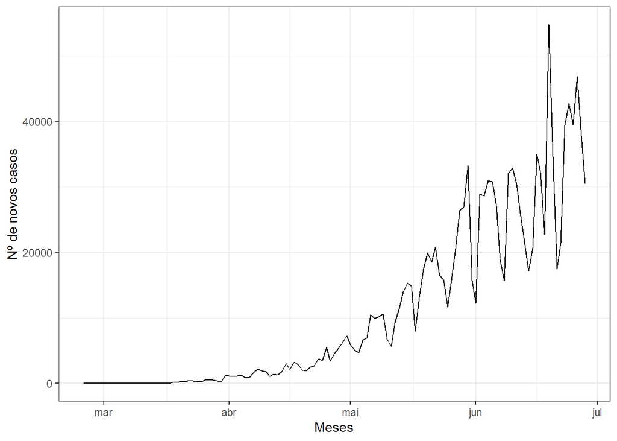

```r
g_casos_novos <- ggplot(covid, aes(data, casosNovos))+
  geom_line()+
  theme_bw()+
  labs(x="Meses", y="Nº de novos casos")

g_casos_novos
```

Cara olha esse pico ali depois da metade de JUNHO, realmente em JUNHO tivemos o nosso pico de casos novos. Mas será que em JUNHO por ter mais casos tivemos mais mortes?

Vamos descobrir

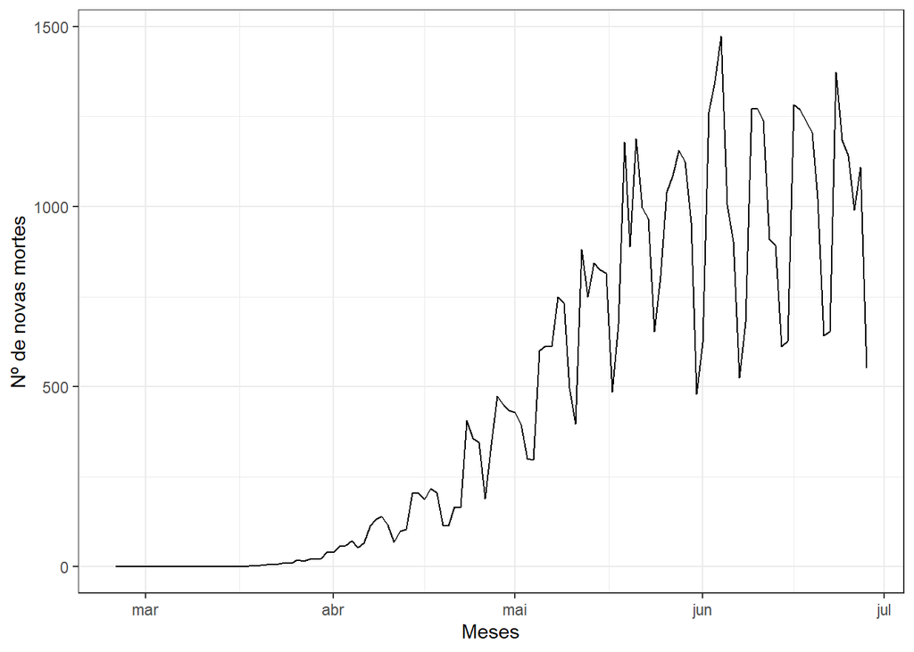

```r
g_obitos_novos <- ggplot(covid, aes(x=data, y=obitosNovos))+
  geom_line()+
  theme_bw()+
  labs(x="Meses", y="Nº de novas mortes")

g_obitos_novos
```

Infelizmente é muita morte :(

Continuando vamos ver quando os óbitos começaram a crescer. Vou definir que a cor mais fraca do gráfico é o periodo com mais óbitos registrados.

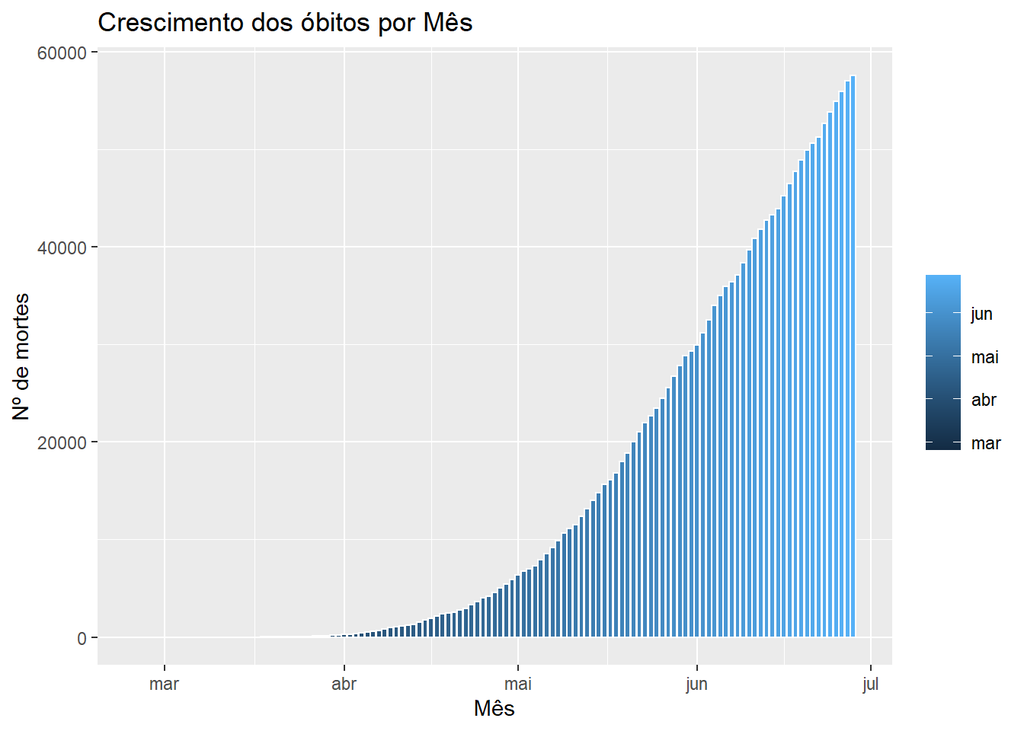

```r
obitos_crescente <- ggplot(covid, aes(x=data, y=obitosAcumulado))+
  geom_col(aes(fill = data), colour = "white")+
  labs(x="Mês", y="Nº de mortes")+
  ggtitle("Crescimento dos óbitos por Mês")+
  theme(legend.title = element_blank())

obitos_crescente
```

## 4 Explorando mais um pouco

Tá agora vamos dar uma melhor explorada nos dados, como por exemplo quais as regições do BRASIL com mais números de casos?

```r
regiao <- dados_covid %>%
  filter(!is.na(estado), is.na(codmun))%>%
  select( -codmun, -codRegiaoSaude, -nomeRegiaoSaude,
         -coduf)

glimpse(regiao)
```

```
## Rows: 3,375
## Columns: 13
## $ regiao                <chr> "Norte", "Norte", "Norte", "Norte", "Norte", ...
## $ estado                <chr> "RO", "RO", "RO", "RO", "RO", "RO", "RO", "RO...
## $ municipio             <chr> NA, NA, NA, NA, NA, NA, NA, NA, NA, NA, NA, N...
## $ data                  <dttm> 2020-02-25, 2020-02-26, 2020-02-27, 2020-02-...
## $ semanaEpi             <dbl> 9, 9, 9, 9, 9, 10, 10, 10, 10, 10, 10, 10, 11...
## $ populacaoTCU2019      <chr> "1777225", "1777225", "1777225", "1777225", "...
## $ casosAcumulado        <dbl> 0, 0, 0, 0, 0, 0, 0, 0, 0, 0, 0, 0, 0, 0, 0, ...
## $ casosNovos            <dbl> 0, 0, 0, 0, 0, 0, 0, 0, 0, 0, 0, 0, 0, 0, 0, ...
## $ obitosAcumulado       <dbl> 0, 0, 0, 0, 0, 0, 0, 0, 0, 0, 0, 0, 0, 0, 0, ...
## $ obitosNovos           <dbl> 0, 0, 0, 0, 0, 0, 0, 0, 0, 0, 0, 0, 0, 0, 0, ...
## $ Recuperadosnovos      <dbl> NA, NA, NA, NA, NA, NA, NA, NA, NA, NA, NA, N...
## $ emAcompanhamentoNovos <dbl> NA, NA, NA, NA, NA, NA, NA, NA, NA, NA, NA, N...
## $ FgMetro               <dbl> NA, NA, NA, NA, NA, NA, NA, NA, NA, NA, NA, N...
```

Pronto agora que conseguimos os estados, vamos agrupar os dados e plotar mais um gráfico para ver a pandemia por região.

Separando as regiões

```r
covid_regiao <- regiao %>%
  group_by(regiao, data) %>%
  summarise(casosNovos = sum(casosNovos),
            casosAcumulado = sum(casosAcumulado),
            obitosNovos = sum(obitosNovos),
            obitosAcumulado = sum(obitosAcumulado))%>%
  filter(data >= lubridate::dmy("01-04-2020")) # dmy:day-month-year
glimpse(covid_regiao)
```

```
## Rows: 445
## Columns: 6
## Groups: regiao [5]
## $ regiao          <chr> "Centro-Oeste", "Centro-Oeste", "Centro-Oeste", "Ce...
## $ data            <dttm> 2020-04-01, 2020-04-02, 2020-04-03, 2020-04-04, 20...
## $ casosNovos      <dbl> 34, 28, 62, 81, 33, 26, 49, 59, 61, 52, 54, 58, 51,...
## $ casosAcumulado  <dbl> 504, 532, 594, 675, 708, 734, 783, 842, 903, 955, 1...
## $ obitosNovos     <dbl> 0, 1, 3, 2, 1, 5, 3, 2, 2, 2, 3, 4, 5, 2, 0, 6, 0, ...
## $ obitosAcumulado <dbl> 5, 6, 9, 11, 12, 17, 20, 22, 24, 26, 29, 33, 38, 40...
```

Show de bola, agora vamos ver os casos por Região.

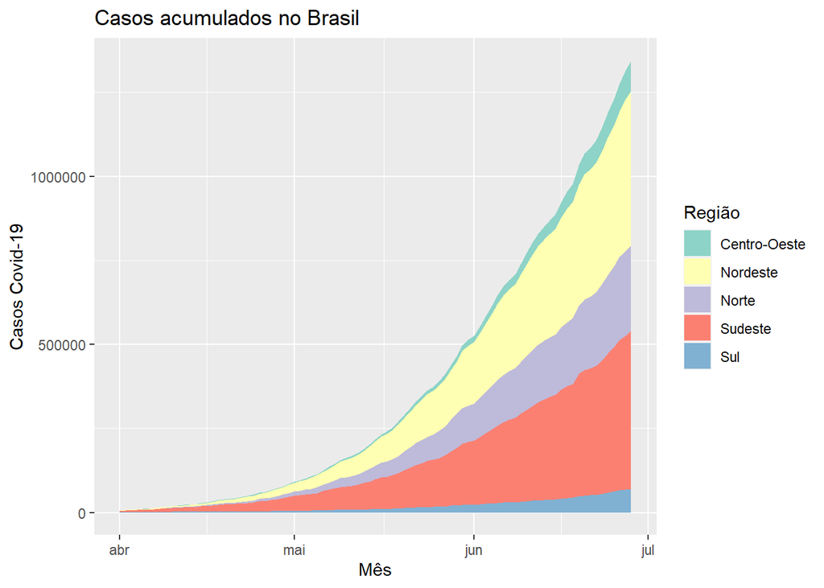

```r
plot_regiao <- ggplot(covid_regiao, aes(data, casosAcumulado)) +
  geom_area(aes(fill = regiao)) +
  scale_fill_brewer(name = "Região", palette = "Set3") +
  labs(x = "Mês", y = "Casos Covid-19") +
  ggtitle("Casos acumulados no Brasil")

plot_regiao
```

Olha só a região Nordeste é meu filho tem comer mais RAPADURA e tomar mais cachaça com mel e limão.

## 5 Isolando

```r
casos_nordeste_centro_oeste <- covid_regiao %>%
  filter(regiao == "Nordeste" | regiao == "Sudeste")%>%
  mutate(data=as.Date(data, format = "%Y-%m-%d"))
casos_nordeste_centro_oeste
```

```
## # A tibble: 178 x 6
## # Groups:   regiao [2]
##    regiao   data       casosNovos casosAcumulado obitosNovos obitosAcumulado
##    <chr>    <date>          <dbl>          <dbl>       <dbl>           <dbl>
##  1 Nordeste 2020-04-01        130           1005           5              27
##  2 Nordeste 2020-04-02        175           1180          16              43
##  3 Nordeste 2020-04-03        219           1399           8              51
##  4 Nordeste 2020-04-04        243           1642           8              59
##  5 Nordeste 2020-04-05        238           1880          19              78
##  6 Nordeste 2020-04-06        287           2167          14              92
##  7 Nordeste 2020-04-07        250           2417          11             103
##  8 Nordeste 2020-04-08        408           2825          38             141
##  9 Nordeste 2020-04-09        417           3242          32             173
## 10 Nordeste 2020-04-10        286           3528          21             194
## # ... with 168 more rows
```

Curva de crescimento de casos…

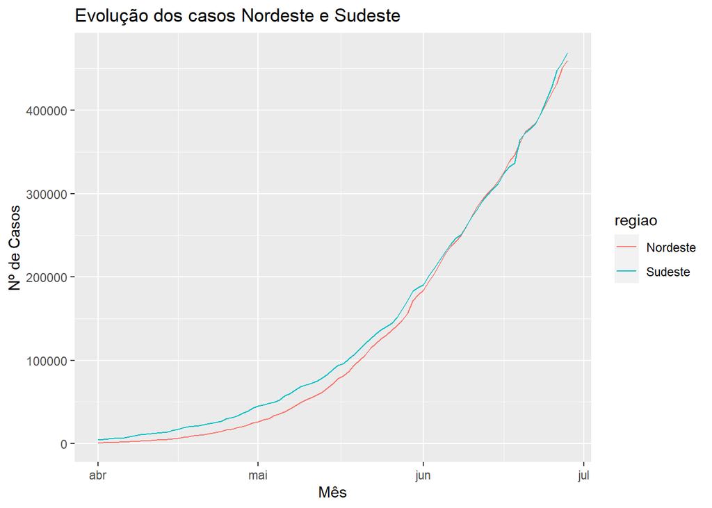

```r
ggplot(casos_nordeste_centro_oeste, aes(x=data, y=casosAcumulado,
                                        color=regiao)) +
  geom_line()+
  scale_fill_brewer(name = "Região") +
  labs(x = "Mês", y = "Nº de Casos") +
  ggtitle("Evolução dos casos Nordeste e Sudeste")
```

## 6 Casos Nordeste

Primeiro vamos filtrar o Nordeste para avaliar só ele… Não queremos ele misturado com outras gentalhas.

```r
casos_nordeste <- regiao %>%
  filter(regiao == "Nordeste")%>%
  mutate(data=as.Date(data, format = "%Y-%m-%d"))
casos_nordeste
```

```
## # A tibble: 1,125 x 13
##    regiao estado municipio data       semanaEpi populacaoTCU2019 casosAcumulado
##    <chr>  <chr>  <chr>     <date>         <dbl> <chr>                     <dbl>
##  1 Norde~ MA     <NA>      2020-02-25         9 7075181                       0
##  2 Norde~ MA     <NA>      2020-02-26         9 7075181                       0
##  3 Norde~ MA     <NA>      2020-02-27         9 7075181                       0
##  4 Norde~ MA     <NA>      2020-02-28         9 7075181                       0
##  5 Norde~ MA     <NA>      2020-02-29         9 7075181                       0
##  6 Norde~ MA     <NA>      2020-03-01        10 7075181                       0
##  7 Norde~ MA     <NA>      2020-03-02        10 7075181                       0
##  8 Norde~ MA     <NA>      2020-03-03        10 7075181                       0
##  9 Norde~ MA     <NA>      2020-03-04        10 7075181                       0
## 10 Norde~ MA     <NA>      2020-03-05        10 7075181                       0
## # ... with 1,115 more rows, and 6 more variables: casosNovos <dbl>,
## #   obitosAcumulado <dbl>, obitosNovos <dbl>, Recuperadosnovos <dbl>,
## #   emAcompanhamentoNovos <dbl>, FgMetro <dbl>
```

Feito! Agora vamos ter uma visão Geral dos dados do Nordeste

```r
summary(casos_nordeste)
```

```
##     regiao             estado           municipio              data
##  Length:1125        Length:1125        Length:1125        Min.   :2020-02-25
##  Class :character   Class :character   Class :character   1st Qu.:2020-03-27
##  Mode  :character   Mode  :character   Mode  :character   Median :2020-04-27
##                                                           Mean   :2020-04-27
##                                                           3rd Qu.:2020-05-28
##                                                           Max.   :2020-06-28
##
##    semanaEpi     populacaoTCU2019   casosAcumulado     casosNovos
##  Min.   : 9.00   Length:1125        Min.   :     0   Min.   :   0.0
##  1st Qu.:13.00   Class :character   1st Qu.:    19   1st Qu.:   2.0
##  Median :18.00   Mode  :character   Median :  1372   Median : 106.0
##  Mean   :17.71                      Mean   : 10481   Mean   : 408.6
##  3rd Qu.:22.00                      3rd Qu.: 12557   3rd Qu.: 531.0
##  Max.   :27.00                      Max.   :107568   Max.   :8822.0
##
##  obitosAcumulado   obitosNovos    Recuperadosnovos emAcompanhamentoNovos
##  Min.   :   0.0   Min.   :  0.0   Min.   : NA      Min.   : NA
##  1st Qu.:   0.0   1st Qu.:  0.0   1st Qu.: NA      1st Qu.: NA
##  Median :  57.0   Median :  4.0   Median : NA      Median : NA
##  Mean   : 495.6   Mean   : 16.5   Mean   :NaN      Mean   :NaN
##  3rd Qu.: 484.0   3rd Qu.: 20.0   3rd Qu.: NA      3rd Qu.: NA
##  Max.   :5990.0   Max.   :261.0   Max.   : NA      Max.   : NA
##                                   NA's   :1125     NA's   :1125
##     FgMetro
##  Min.   : NA
##  1st Qu.: NA
##  Median : NA
##  Mean   :NaN
##  3rd Qu.: NA
##  Max.   : NA
##  NA's   :1125
```

Vamos organizar e procurar informações.

Por exemplo qual a média de casos novos por dia ?

```r
media_casos_novos <- mean(casos_nordeste$casosNovos)
media_casos_novos
```

```
## [1] 408.6293
```

E qual a média de óbitos ?

```r
media_obitos <- mean(casos_nordeste$obitosNovos)
media_obitos
```

```
## [1] 16.50311
```

E o crescimento dos casos no Nordeste

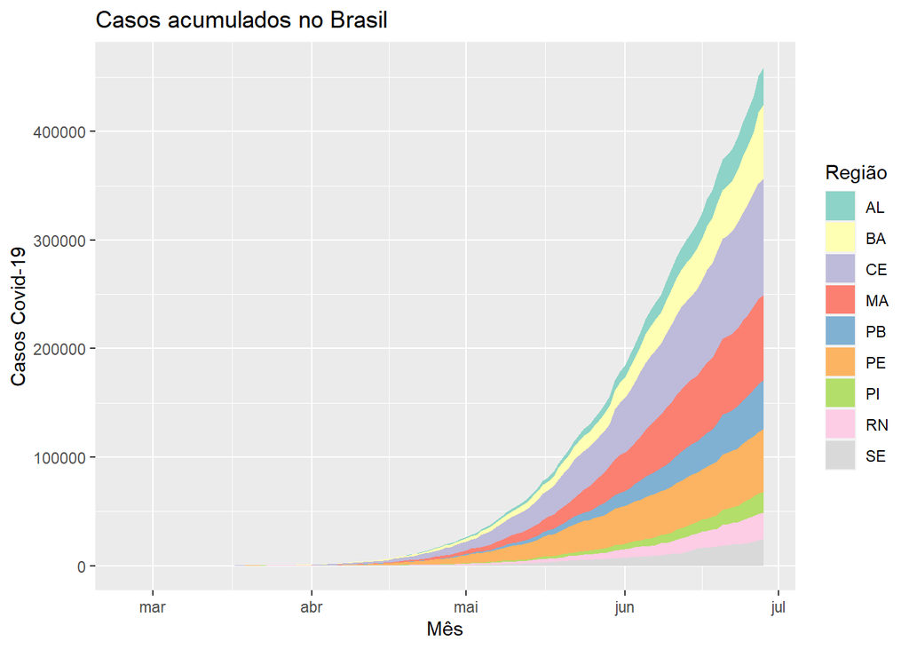

```r
plot_regiao_nordeste <- ggplot(casos_nordeste, aes(data, casosAcumulado)) +
  geom_area(aes(fill = estado)) +
  scale_fill_brewer(name = "Região", palette = "Set3") +
  labs(x = "Mês", y = "Casos Covid-19") +
  ggtitle("Casos acumulados no Brasil")

plot_regiao_nordeste
```

Estados dos Nordeste com mais casos…

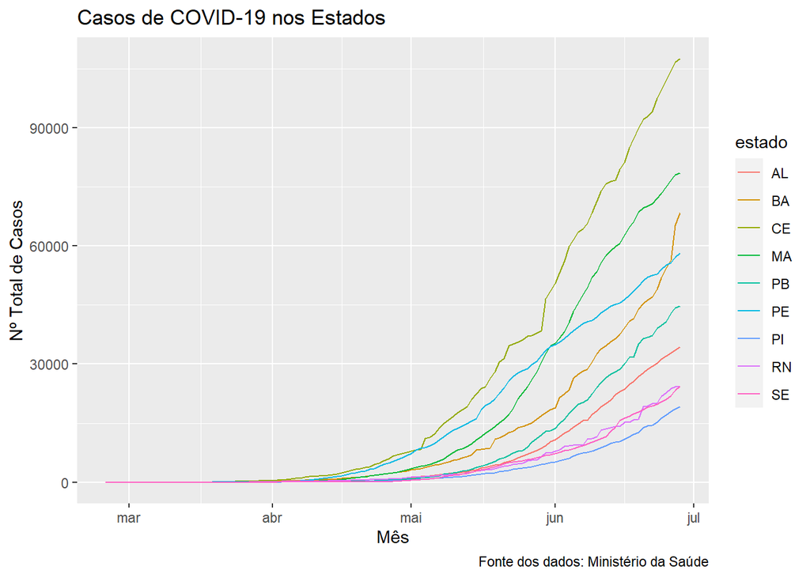

```r
ggplot(casos_nordeste, aes(data, casosAcumulado))+
  geom_line(aes(fill=estado, colour = estado))+
  labs(title = "Casos de COVID-19 nos Estados", x="Mês", y="Nº Total de Casos",
       caption = "Fonte dos dados: Ministério da Saúde")
```

Gráficamente falando ta uma bosta kkkkkk da pra entender nada ai, mas vamos melhorar. Vamos separar cada estado.

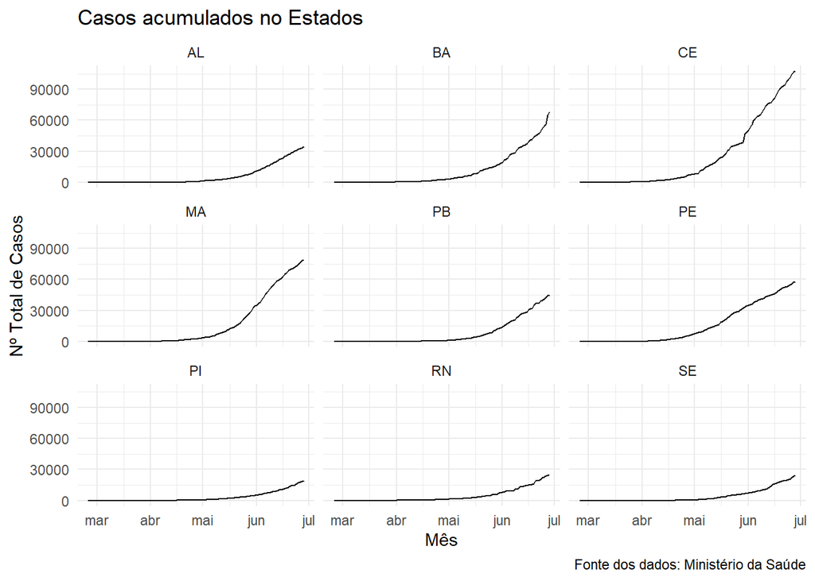

```r
plot_casos_estados_nordeste <- ggplot(casos_nordeste, aes(data, casosAcumulado))+
  geom_line()+
   labs(title = "Casos acumulados no Estados",x="Mês", y="Nº Total de Casos",
       caption = "Fonte dos dados: Ministério da Saúde") +
facet_wrap(vars(estado), ncol=3)

plot_casos_estados_nordeste + theme_minimal()
```

Bem, eu ainda queria fazer uma análise da Paraíba especificamente mas fica para a próxima.

Então até mais essa GALERA, se cuidem, lavem as mãos e usem mascara. VLW FLW